# Simulación

León Berdichevsky Acosta

18 de septiembre de 2018

### Teoría básica de simulación

La simulación de un modelo consiste en la construcción de un programa computacional que permite obtener los valores de las varibles de salida para distintos valores de las variables de entrada con el objetivo de obtener conclusiones del sistema que apoyen la toma de decisiones (explicar y/o predecir el comportamiento del sistema).

Requerimientos prácticos de un proyecto de simulación:

- Fuente de números aleatorios $U(0,1)$ (números pseudoaleatorios).
- Transformar los número aleatorios en variables de entrada del modelo (e.g. generación de muestras de cierta distribución).
- Construir el programa computacional de simulación.
- Analizar las distintas simulaciones del modelo para obtener conclusiones acerca del sistema.

#### Números pseudoaleatorios

El objetivo es generar sucesiones $\{u_i\}_{i=1}^N$ de números independientes que se puedan considerar como observaciones de una distribución uniforme en el intervalo $(0, 1)$.

1. **Verdaderos números aleatorios** Los números completamente aleatorios (no determinísticos) son fáciles de imaginar conceptualmente, por ejemplo podemos imaginar lanzar una moneda, lanzar un dado, una lotería.

En general los números aleatorios se basan en alguna fuente de aleatoreidad física que puede ser teóricamente impredecible (cuántica) o prácticamente impredecible (caótica). Por ejemplo, random.org genera aleatoreidad a través de ruido atmosférico (el paquete random consiste en funciones para obtener números de random.org), y ERNIE, usa ruido térmico en transistores.

La desventaja de éstos métodos es que son costosos, tardados y no son reproducibles.

2. **Números pseudoaleatorios** Los números pseudoaleatorios se generan de manera secuencial con un algoritmo determinístico, formalmente se define por una función de inicialización, un estado, una función de transición y una función que genera salidas:
   - **Función de inicialización**. Recibe un número (la semilla) y pone al generador en su estado inicial.
   - **Función de transición**. Transforma el estado del generador.
   - **Función de salidas**. Transforma el estado para producir un número fijo de bits (0 ó 1).

Una sucesión de bits pseudoaleatorios se obtiene definiendo la semilla y llamando repetidamente la función de transición y la función de salidas. Esto implica, entre otras cosas, que la sucesión de números generados esta completamente determinada por la semilla.

**Ejemplo**. Por muchos años (antes de 1995) el generador de la función *rand* en Matlab fue el generador congruencial:

$$X_{n+1} = (7^5)X_n mod(2^{31}-1)$$

```r
## construyamos sucesiones de longitud n usando el algoritmo de rand
sucesion <- function(n = 1500, semilla = runif(1, 0, 2 ^ 31 - 1)){
    x <- rep(NA, n)
    u <- rep(NA, n)
    x[1] <- semilla # semilla
    u[1] <- x[1] / (2 ^ 31 - 1) # transformamos al (0, 1)
    for(i in 2:n){
        x[i] <- (7 ^ 5 * x[i - 1]) %% (2 ^ 31 - 1)
        u[i] <- x[i] / (2 ^ 31 - 1)
    }
    u
}
u_rand <- sucesion(n = 150000)
sucesiones <- map_df(1:12, ~data_frame(serie = ., sim = sucesion(), ind = 1:length(sim)))
sucesiones
```

```
#> # A tibble: 18,000 x 3
#>    serie     sim   ind
#>    <int>   <dbl> <int>
#>  1     1 0.545       1
#>  2     1 0.0641      2
#>  3     1 0.00391     3
#>  4     1 0.796       4
#>  5     1 0.814       5
#>  6     1 0.469       6
#>  7     1 0.506       7
#>  8     1 0.547       8
#>  9     1 0.211       9
#> 10     1 0.372      10
#> # ... with 17,990 more rows
```

Una propiedad deseable es que la sucesión de $u_i$ parezca una sucesión de observaciones independientes de una $Uniforme(0,1)$.

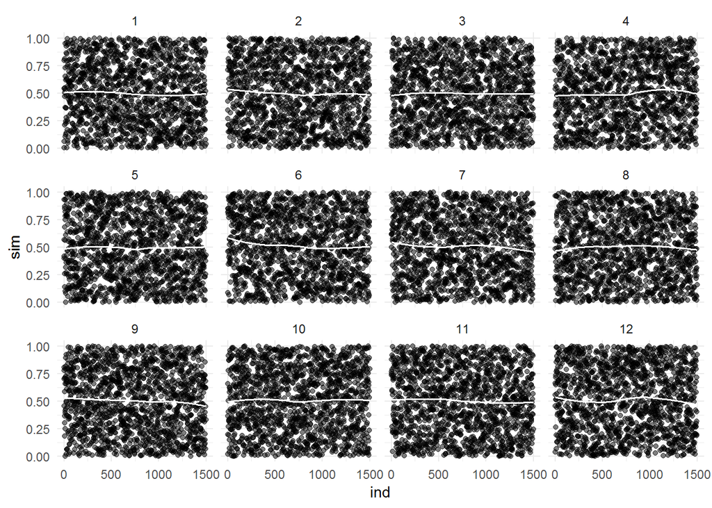

```r
# veamos una gráfica del índice de simulación contra el valor obtenido
ggplot(sucesiones, aes(x = ind, y = sim)) +
  geom_point(alpha = 0.5, size = 1.5) +     # alpha controla la transparencia
  facet_wrap(~ serie) +
  geom_smooth(method = "loess", se = FALSE, color = "white", size = 0.7)
```

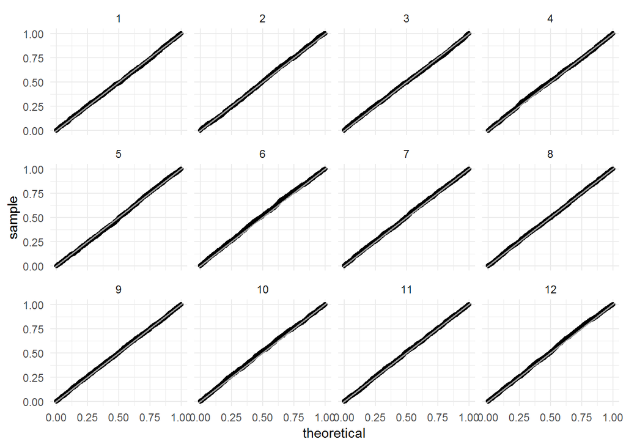

```r
# comparemos con los cuantiles de una uniforme
ggplot(sucesiones) +
  stat_qq(aes(sample = sim), distribution = qunif) +
  geom_abline(color = "white", size = 0.6, alpha = 0.6) +
  facet_wrap(~ serie)
```

Una buena secuencia de números pseudoaleatorios no muestra ningún patrón o regularidad aparente desde un punto de vista estadístico. Otra caraceterística importante es que dada una semilla inicial, el número de variables que se pueden generar antes de repetir el ciclo es grande. Construir un buen algoritmo de números pseudo aleatorios es complicado ([(Random.org)](https://www.random.org)).

**Ejemplo**. Un generador de números aleatorios ampliamente utilizado en los 60´s y 70´s fue RANDU, que se define como:
$$X_{n + 1}= (2 ^ {16} + 3)X_n mod(2^{31})$$

A primera vista las sucesiones se asemejan a una uniforme; sin embargo, cuando se grafican ternas emergen patrones no deseados.

```r
# correr este código como shiny app para que funcione la siguiente gráfica
# interactiva
library(tourr)
library(ggvis)
library(shiny)

n <- 1500 # longitud de la sucesión
x <- rep(NA, n)
u <- rep(NA, n)

x[1] <- 4798373 # semilla
u[1] <- x[1] / (2 ^ 31 - 1) # transformamos al (0, 1)
for(i in 2:n){
    x[i] <- ((2 ^ 16 + 3) * x[i - 1]) %% (2 ^ 31)
    u[i] <- x[i] / (2 ^ 31)
}

aps <- 2
fps <- 30

mat <- scale(matrix(x, ncol = 3, byrow= TRUE))
tour <- new_tour(mat, grand_tour(), NULL)
start <- tour(0)

proj_data <- reactive({
    invalidateLater(1000 / fps, NULL);
    step <- tour(aps / fps)
    data.frame(center(mat %*% step$proj))
})

proj_data %>% ggvis(~X1, ~X2) %>%
    layer_points() %>%
    scale_numeric("x", domain = c(-1, 1)) %>%
    scale_numeric("y", domain = c(-1, 1)) %>%
    set_options(duration = 20)
```

Veamos los resultados enteros del generador, ¿qué notas?

```r
options(digits=5)
n <- 50
x <- rep(NA, n)
x[1] <- 1 # semilla
u[1] <- x[1] # transformamos al (0, 1)
for(i in 2:n){
    x[i] <- ((2 ^ 16 + 3) * x[i - 1]) %% (2 ^ 31)
}
x
```

```
#>  [1]          1      65539     393225    1769499    7077969   26542323
#>  [7]   95552217  334432395 1146624417 1722371299   14608041 1766175739
#> [13] 1875647473 1800754131  366148473 1022489195  692115265 1392739779
#> [19] 2127401289  229749723 1559239569  845238963 1775695897  899541067
#> [25]  153401569 1414474403  663781353 1989836731 1670020913  701529491
#> [31] 2063890617 1774610987  662584961  888912771 1517695625 1105958811
#> [37] 1566426833 1592415347 1899101529 1357838347 1792534561  682145891
#> [43]  844966185 1077967739 1010594417  656824147 1288046073 1816859115
#> [49] 1456223681  975544643
```

Los generadores $X_{n+1} = (7^5)X_n mod(2^{31}-1)$ y $X_{n + 1}= (2 ^ {16} + 3)X_n mod(2^{31})$ se denominan congruenciales pues tienen la forma:

$$X_{n+1} = (aX_n + c)mod(m)$$
los generadores con esta forma se conocen como Generadores Congruenciales Lineales (GCL), se introdujeron en 1949 por D.H. Lehemer y son muy [populares](https://en.wikipedia.org/wiki/Linear_congruential_generator). La elección de los parámetros determina la calidad del generador:

$$m > 0, \mbox{ módulo}\\
0\le a < m, \mbox{ multiplicador} \\
c \le m, \mbox{ incremento}\\
0\le X_0 < m, \mbox{ semilla}$$

- Queremos $m$ grande pues el periodo (longitud del ciclo) del generador no puede tener más de $m$ elementos.
- Otra consideración es que queremos velocidad, en este caso, un valor conveniente para $m$ es el *tamaño de palabra* (máximo número de bits que puede procesar el CPU en un ciclo) de la computadora. Los GCL más eficientes tienen $m$ igual a una potencia de 2 (es usual 2<sup>32</sup> o 2<sup>64</sup>) de esta manera la operación módulo se calcula truncando todos los dígitos excepto los últimos 32 o 64 bits.
- ¿podemos elegir $a$ y $c$ y lograr alcanzar el periodo máximo ($m$)?

Un generador congruencial mixto ($c>0$) tendrá periodo completo para todas las semillas sí y sólo sí:

- $m$ y $c$ son primos relativos.
- $a-1$ es divisible por todos los factores primos de $m$.
- $a-1$ es divisible por 4 si $m$ es divisible por 4.

Un periodo grande no determina que el generador congruencial es *bueno*, debemos verificar que los números que generan se comportan como si fueran aleatorios. Los GCLs tienden a exhibir defectos, por ejemplo, como observamos con RANDU, si se utiliza un GCL para elegir puntos en un espacio de dimensión $k$ los puntos van a caer en a lo más $(k!m)^{1/k}$) hiperplanos paralelos $k$ dimensionales, donde $k$ se refiere a la dimensión de $[0,1]^k$ .

Los GCLs continuan siendo utilizados en muchas aplicaciones porque con una elección cuidadosa de los parámetros pueden pasar pruebas de aleatoriedad, son rápidos y requiren poca memoria, sin embargo, el generador actual de R no es de esta clase, se conoce como *Mersenne-Twister* (este es el default pero hay varios generadores disponbiles, ver ?Random).

### Mersenne-Twister

El generador Mersenne-Twister se desarrolló en 1997 por Makoto Matsumoto y Takuji Nishimura, es el generador default en muchos programas, por ejemplo, en Python, Ruby, C++ estándar, Excel y Matlab (más [aquí](https://en.wikipedia.org/wiki/Mersenne_Twister)). Este generador tiene propiedades deseables como un periodo largo (2^19937-1) y el hecho que pasa muchas pruebas de aleatoriedad.

### Pruebas de aleatoriedad

Hasta ahora hemos graficado las secuencias de números aleatorios para evaluar su aleatoriedad, sin embargo, el ojo humano no es muy bueno discriminando aleatoriedad y las gráficas no escalan. Es por ello que resulta conveniente hacer pruebas estadísticas para evaluar la calidad de los generadores de números pseudoaleatorios.

Hay dos tipos de pruebas: 1) empíricas, donde evaluamos estadísticas de sucesiones de números y 2) teóricos, donde se establecen las características de las sucesiones usando métodos de teoría de números con base en la regla de recurrencia que generó la sucesión. Veremos 2 ejemplos de la primera clase.

#### Prueba de bondad de ajuste $\chi^2$

$H_0:$ Los datos son muestra de una cierta distribución $F$.  
$H_1:$ Los datos no son una muestra de $F$.

Procedimiento:

1. Partir el soporte de $F$ en $c$ celdas que son exhaustivas y mutuamente exculyentes.
2. Contar el número de observaciones en cada celda $O_i$.
3. Calcular el valor esperado en cada celda bajo $F$: $e_i=np_i$.
4. Calcular la estadística de prueba:

$$\chi^2 = \sum_{i=1}^c \frac{(O_i - e_i)^2}{e_i} \sim \chi^2_{c-k-1}$$
donde $c$ es el número de celdas y $k$ el número de parámetros estimados en $F$ a partir de los datos observados.

```r
u_rand_cat <- cut(u_rand, breaks = seq(0, 1, 0.1))
u_randu_cat <- cut(u_randu, breaks = seq(0, 1, 0.1))
u_mt <- runif(150000)
u_mt_cat <- cut(u_mt, breaks = seq(0, 1, 0.1))

chisq.test(table(u_rand_cat))
```

```
#>
#>  Chi-squared test for given probabilities
#>
#> data:  table(u_rand_cat)
#> X-squared = 7.44, df = 9, p-value = 0.59
```

```r
chisq.test(table(u_randu_cat))
```

```
#>
#>  Chi-squared test for given probabilities
#>
#> data:  table(u_randu_cat)
#> X-squared = 3.05, df = 9, p-value = 0.96
```

```r
chisq.test(table(u_mt_cat))
```

```
#>
#>  Chi-squared test for given probabilities
#>
#> data:  table(u_mt_cat)
#> X-squared = 13.4, df = 9, p-value = 0.15
```

Una variación de esta prueba de bondad de ajuste $\chi^2$, es la prueba de u uniformidad k-dimensional:

$H_0:$ Distribución uniforme en $[0,1]^k$, con $k = 1,2,...$

En este caso se divide el espacio $[0,1]^k$ en celdas exhaustivas y mutuamente excluyentes, y se aplica la prueba $\chi^2$ a los vectores sucesivos $(u_1,u_2,...,u_k),(u_{k+1},u_{k+2},...,u_{2k}),...$

### Prueba de espera

Busca probar independencia y uniformidad

Procedimiento:  
1. Seleccionar un subintervalo del $(0,1)$.  
2. Calcular la probabilidad del subintervalo.  
3. Ubicar en la sucesión las posiciones de los elementos que pertenezcan al subintervalo.  
4. Calcular el número de elementos consecutivos de la sucesión entre cada una de las ocurrencias consecutivas de elementos del subintervalo (*tiempos de espera*).  
5. La distribución de los tiempos de espera es geométrica con parámetro calculado en 2.  
6. Aplicar una prueba $\chi^2$ a los tiempos de espera.

```r
library(randtoolbox)
gap.test(u_mt)
```

[output not shown]

[output cut: 16 more lines]

```r
gap.test(u_randu)
```

```
#>
#>           Gap test
#>
#> chisq stat = 14, df = 17, p-value = 0.66
#>
#>       (sample size : 150000)
#>
#> length   observed freq       theoretical freq
#> 1             18816           18750
#> 2             9219            9375
#> 3             4679            4688
#> 4             2385            2344
#> 5             1227            1172
#> 6             612             586
#> 7             287             293
#> 8             131             146
#> 9             72              73
#> 10            36              37
#> 11            14              18
#> 12            7           9.2
#> 13            3           4.6
#> 14            1           2.3
#> 15            0           1.1
#> 16            0           0.57
#> 17            0           0.29
#> 18            0           0.14
```

Otras pruebas de aleatoriedad son *prueba de rachas*, *Kolmogorov-Smirnov*, *prueba de poker*, puedes leer más de generadores aleatorios y pruebas en *The Art Computer of Programming* de Donald Knuth. En R hay pruebas implementadas en los paquetes `randtoolbox`y `RDieHarder`.

### Simulación de variables aleatorias discretas

Veremos métodos generales para simular muestras de distribuciones univariadas, generales se refiere a que se pueden utilizar independientemente de la forma de la función de densidad.

Para utilizar estos métodos debemos tener un generador de números aleatorios confiable. En general, la mayoría de los métodos consisten en una transformación de números aleatorios.

#### Método de Inversión

Supongamos que deseamos generar el valor de una variable aleatoria discreta $X$ con función de probabilidad:
$$P(X=x_j) = p_j$$
con $j=1,2,..$.

Para lograr esto generamos un número aleatorio $U$, esto es $U\sim Uniforme(0,1)$ y definimos

$$X = \left\{
\begin{array}{lr}
x_0 & U < p_0\\
x_1 & p_0 \leq U < p_0 + p_1\\
\vdots &\\
x_j & \sum_{i=0}^{j-1}p_i \leq U < \sum_{i=0}^j p_i \\
\vdots & \\
\end{array}
\right.$$

Como para $0<a<b<1$ tenemos que $P(a\leq U < b)=b-a$, tenemos que
$$P(X=x_j)=P\bigg\{\sum_{i=0}^{j-1}p_i \leq U < \sum_{i=0}^{j}p_i \bigg \}=p_j$$
y por tanto $X$ tiene la distribución deseada.

**Método de inversión**

1. Genera un número aleatorio $U$, tal que $U \in (0,1)$.  
   Si $U<p_0$ define $X=x_0$ y para.  
   Si $U< p_0+p_1$ define $X = x_1$ y para.  
   Si $U < p_0 + p_1 + p_2$ define $X=x_2$ y para.  
   $\vdots$
2. Si las $x_i$, están ordenadas de tal manera que $x_0<x_1<x_2<\cdots$ y si denotamos por $P$ la función de distribución acumulada de $X$, entonces $P(x_k)=\sum_{i=0}^kp_i$ y por tanto, $X$ será igual a $x_j$ si
   $$P(x_{j-1}) \leq U \leq P(x_j)$$
   . En otras palabras, tras generar un número aleatorio $U$ determinamos el valor de $X$ encontrando el intervalo $[P(x_{j-1}),P(x_j))$ en el que cae $U$, esto es equivalente a encontrar la inversa de $P(U)$.

El tiempo que uno tarda en generar una variable aleatoria discreta usando el método de arriba es proporcional al número de intervalos que uno debe buscar, es por esto que en ocasiones vale la pena considerar los posibles valores $x_j$ en orden decreciente de $p_j$.

Utiliza la función runif de R y el método de inversión para generar 1000 simulaciones de una variable aleatoria $X$ tal que $p_1=0.20, p_2= 0.15, p_3=0.25, p_4=0.40$ donde $p_j=P(X=j)$.

Ejemplo **Uniforme discreta**: Supongamos que deseamos simular de una variable aleatoria uniforme discreta que toma valores $1,...,k$, usando los resultados anteriores tenemos que:

$X=j$ si $\frac{j-1}{n} \leq U < \frac{j}{n}$

Entonces $X=[kU] + 1$, donde $[x]$ representa la parte entera de x.

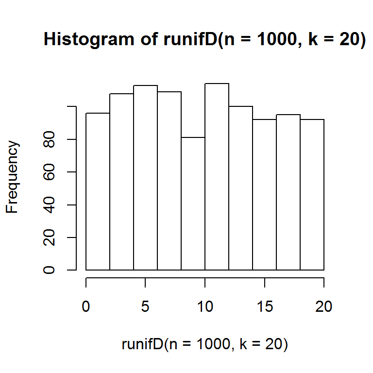

```r
# uniforme discreta: donde n es el número de simulaciones y k el número de elementos
runifD <- function(n = 1, k) floor(k * runif(n)) + 1
# veamos un histograma de 1000 simulaciones de una distribución Uniforme
# discreta con parámetro k = 20
hist(runifD(n = 1000, k = 20))
```

```r
# También podmeos usar la función sample de R
# hist(sample(1:20, size = 1000, replace= TRUE))
```

Ejemplo **Poisson**: la clave para usar el método de la transformación inversa en este ejemplo es notar que:
$$p_{i+1}=\frac{\lambda}{i+1}p_i$$

donde $p_i=P(X=i) = e^-{\lambda} \lambda^i/i!$, con $i=0,1,...$. Ahora, la cantidad $i$ se refiere al valor que estamos considerando, $p=p_i$ es la probabilidad de $X = i$ y $P=P(i)$ es la probabilidad de $X\leq i$. Entonces, para generar una observación sequimos los siguientes pasos:

1. Generar un número aleatorio $U$, tal que $U \in (0,1)$.
2. Inicializar: $i=0$, $p=e^{-\lambda}$, $F=p$.
3. Si $U<F$, definir $X=i$ y parar.
4. $p=\lambda p/(i+1)$, $F=F+p$, $i=i+1$.
5. Volver a 3.

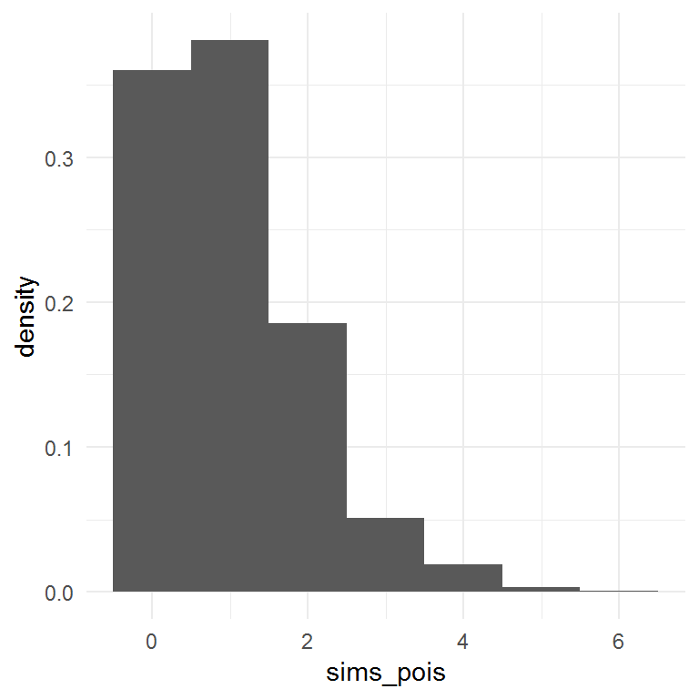

```r
# Poisson usando Inversión
rpoisI <- function(lambda = 1){
  U <- runif(1)
  i <- 0
  p <- exp(-lambda)
  P <- p
  while(U >= P){
    p <- lambda * p / (i + 1)
    P <- P + p
    i <- i + 1
  }
  i
}
sims_pois <- rerun(2000, rpoisI()) %>% flatten_dbl()

ggplot() +
    geom_histogram(aes(x = sims_pois, y = ..density..), binwidth = 1)
```

El algoritmo que propusimos verifica de manera sucesiva si el valor es 0, 1, etc. por lo que el número de comparaciones necesarias será uno más que el valor de la variable. Ahora, el valor esperado de una variable aleatoria Poisson es $\lambda$ por lo que en promedio se harían $1+\lambda$ busquedas. Cuando $\lambda$ es grande se puede mejorar el algotitmo buscando primero en valores cercanos a $\lambda$.

- Escribe una función en R que genere simulaciones de una variable aleatoria Poisson de la siguiente manera: define $I=[\lambda]$, y usa que $p_{i+1}=\lambda p_i /(i+1)$ para determinar $F$ de manera recursiva. Genera un número aleatorio $U$, determina si $X \leq I$ comparando si $U \leq F(I)$. Si $X \leq I$ busca hacia abajo comenzando en $I$, de lo contrario busca hacia arriba comenzando por $I+1$. Compara el tiempo que tardan los dos algoritmos en 5000 simulaciones de una variable aleatoria Poisson con parámetro $\lambda=10, 200, 500$.

#### Aceptación y rechazo

Supongamos que tenemos un método eficiente para generar simulaciones de una variable aleatoria con función de probabilidad masa $\{q_j, j\geq 0\}$, podemos usarla como la base para simular de una distribución que tiene función de probabilidad masa $\{p_j, j \geq 0\}$, para hacer esto comenzamos simulando una variable aleatoria $Y$ con función $\{q_j\}$ y después aceptamos o rechazamos el valor simulado con una probabilidad proporcional a $p_Y/q_Y$. En particular, sea $c$ una constante tal que
$$\frac{p_j}{q_j}\leq c$$
para toda $j$ con $p_j > 0$. Entonces el método de aceptación y rechazo para simular una variable aleatoria $X$ con función masa de probabilidad $p_j=P(x=j)$ es como sigue:

**Método de aceptación y rechazo**

1. Simula el valor de $Y$, con función de probabilidad masa $q_j$.
2. Genera un número aleatorio $U$, tal que $U \in (0,1)$.
3. Si $U < p_y/(cq_y)$ definimos $X=Y$ y paramos, en otro caso regresamos a 1.

. Supongamos que queremos simular el valor de una variable aleatoria $X$ que toma uno de los valores $1, 2,3,4$ con probabilidades $p_1=0.20, p_2= 0.15, p_3=0.25, p_4=0.40$ donde $p_j=P(X=j)$. Usemos el método de aceptación y rechazo con $q$ la densidad uniforme en $1,...,10$. Implementa una función usando el método de aceptación y rechazo. ¿Cómo se compara en velocidad con la función que implementaste usando el método de la transformación inversa?

### Simulación de variables aleatorias continuas

### Transformación inversa

Sea $U$ una variable aleatoria con ditribución $U(0,1)$. Para cualquier función de distribución $F$ la variable aleatoria $X$ definida como
$$X = F^{-1}(U)$$
tiene distribución $F$.

La proposición anterior nos da un camino para simular variables aleatorias continuas generando un número aleatorio $U$ y definiendo $X = F^{-1}(U)$:

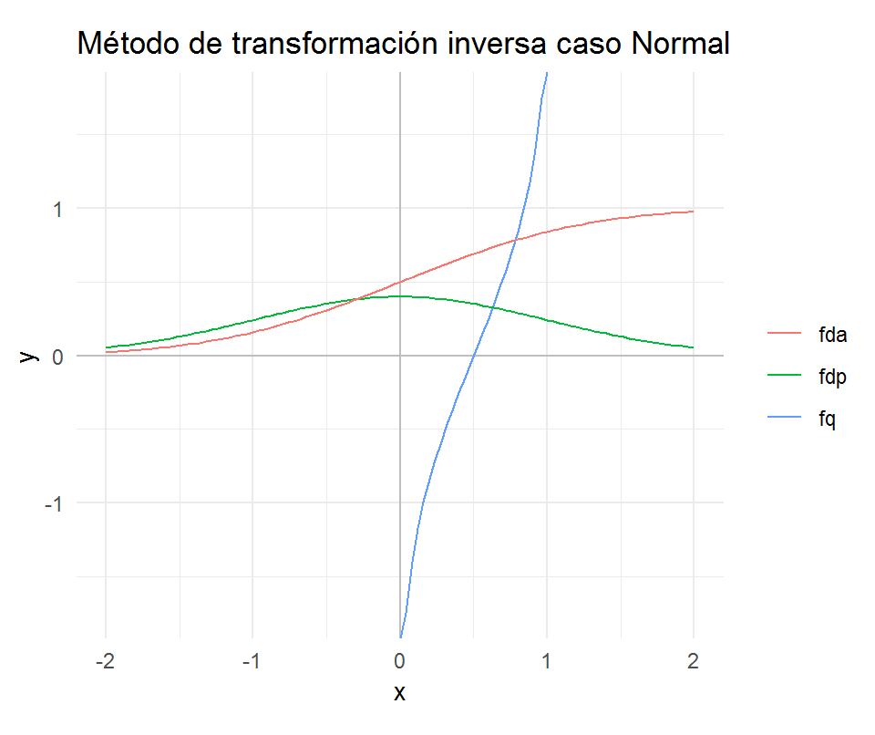

```r
ggplot(data_frame(x = c(-2 , 2)), aes(x)) +
    geom_hline(yintercept = 0, color = "gray") +
    geom_vline(xintercept = 0, color = "gray") +
    stat_function(fun = qnorm, aes(color = "fq")) +
    stat_function(fun = dnorm, aes(color = "fdp")) +
    stat_function(fun = pnorm, aes(color = "fda")) +
    coord_fixed() +
    labs(color = "", title = "Método de transformación inversa caso Normal")
```

#### Ejemplo: Exponencial

Si $X$ es una variable aleatoria exponencial con tasa 1, entonces

$$F(x)=1-e^{-x}$$

Si definimos $x=F^{-1}(u)$, entonces
$$u=F(x)=1-e^{-x}$$
o
$$x = -log(1-u)$$

Vale la pena notar que si $U$ tiene distribución $U(0,1)$, $1-U$ también se distribuye uniforme(0,1).

```r
simExp <- function(){
  u <- runif(1)
  x <- -log(u)
}
```

Notemos que para cualquier constante positiva $c$, $cX$ tiene distribución exponencial con media $c$, por tanto una variable aleatoria exponencial con parámetro $\beta$ se puede generar de la siguiente manera:

$$X=-\beta log(U)$$

```r
simExpBeta <- function(beta){
  -beta * log(runif(1))
}
sims_exp <- rerun(1000, simExpBeta(2)) %>% flatten_dbl()
mean(sims_exp)
```

```
#> [1] 1.9
```

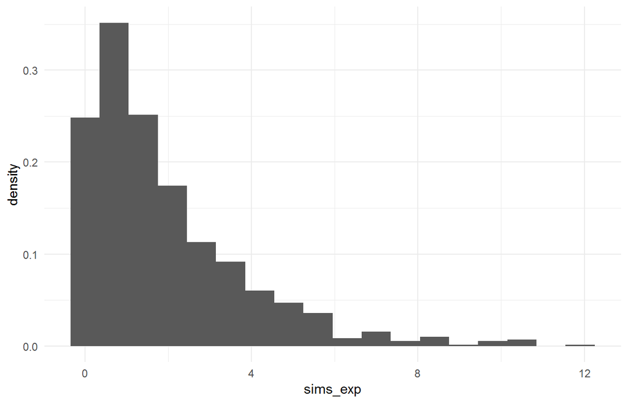

```r
ggplot() +
  geom_histogram(aes(x = sims_exp, y = ..density..), binwidth = 0.7)
```

El algoritmo anterior también provee una manera de generar variables aleatorias Poisson. Primero, recordemos que un proceso Poisson con tasa $\lambda$ resulta cuando los tiempos de espera entre eventos sucesivos son exponenciales independientes con parámetro $\beta$, para este proceso el número de eventos al tiempo 1 se distribuye Poisson con parámetro $\lambda = 1/\beta$. Para este proceso, $N(1)$, el número de eventos en el tiempo 1 se distribuye Poisson con media $1/\beta$. Si denotamos por $X_i$ los tiempos entre eventos, el $n$-ésimo evento ocurrirá en el tiempo $\sum_{i=1}^n X_i$ y por tanto el número de eventos al tiempo 1 se puede expresar como:

$$N(1)=max\bigg\{n: \sum_{i=1}^nX_i \leq 1\bigg\}$$

Esto es, el número de eventos al tiempo 1 es igual a la $n$ mayor para la cual el n-ésimo evento ocurrió al tiempo 1. Por ejemplo, si el cuarto evento ocurrió al tiempo uno pero el quinto no, habría 4 eventos al tiempo 1. Por tanto, usando el ejemplo anterior, podemos generar una variable aleatoria Poisson con media $\lambda = 1/\beta$ generando números aleatorios $U_1,...U_n,...$ y definiendo

$$N=max\bigg\{n: \sum_{i=1}^n -\beta log(U_i)\bigg\}$$
$$=max\bigg\{n: \sum_{i=1}^n -1/\lambda log(U_i)\bigg\}$$
$$=max\bigg\{n:\sum_{i=1}^n log(U_i)\geq -\lambda \bigg\}$$
$$=max\{n:log(U_1\cdot\cdot\cdot U_n) \geq -\lambda\}$$
$$=max\{n: U_1\cdot \cdot \cdot U_n \geq e^{-\lambda}\}$$

Entonces, una variable aleatoria Poisson con media $\lambda$ se puede generar a partir de una sucesión de números aleatorios, generando números hasta que el producto sea menor a $e^{-\lambda}$ y definiendo $X$ como uno menos del número de números aleatorios requeridos.

$$N = min\{n: U_1\cdot\cdot\cdot U_n < e^{-\lambda}\} - 1$$

```r
poisson <- function(lambda){
  u <- runif(1)
  N <- 1
  while(u > exp(-lambda)){
    u <- u * runif(1)
    N <- N + 1
  }
  N - 1
}

poisson(10)
```

```
#> [1] 11
```

```r
mean(rdply(1000, poisson(10))$V1)
```

```
#> [1] 10
```

#### Ejemplo: Gamma

Supongamos que deseamos generar el valor de una variable aleatoria $gamma(n,\beta)$, la función de distribución es,

$$\int_{0}^x \frac{1}{\beta^n \Gamma(n)}x^{n-1}e^{-x/\beta}dy$$

la inversa de la función de distribución acumulada anterior no se puede escribir de forma cerrada. Sin embargo, podemos simular de ella usando que una $gamma(n,\beta)$ se puede ver como la suma de $n$ exponenciales independientes, cada una con parámetro $\beta$:

$$X=-\beta log(U_1)-\cdot\cdot\cdot - \beta log(U_n)$$
$$=-\beta log(U_1\cdot\cdot\cdot U_n)$$

donde la identidad $\sum log(x_i) = log(x_1\cdot\cdot\cdot x_n)$ deriva en ganancias computacionales.

```r
gamma_nb <- function(n, beta){
  -beta * log(Reduce(`*`,runif(10)))
}
sims_gamma <- rdply(1000, gamma_nb(n = 10, beta = 2))
mean(sims_gamma$V1)
```

```
#> [1] 20
```

```r
var(sims_gamma$V1)
```

```
#> [1] 38
```

### Aceptación y rechazo

Supongamos que tenemos un método para generar variables aleatorias con función de densidad $g(x)$, podemos usarla como base para generar observaciones de una variable aleatoria con densidad $f(x)$ generando $Y$ de $g$ y después aceptando el valor generado con una probabilidad proporcional a $f(Y)/g(Y)$. Sea $c$ una constante tal que
$$\frac{f(y)}{g(y)} \leq c$$

para toda $c$, entonces el método se puede escribir como sigue:

**Aceptación y rechazo**

1. Genera $Y$ con densidad $g$.
2. Genera un número aleatorio $U$.
3. Si $U \leq \frac{f(Y)}{cg(Y)}$ define $X=Y$, de lo contrario regresa a 1.

El método de aceptación y rechazo es análogo al correspondiente a variables aleatorias discretas.

1. La variable aleatoria generada usando el método de aceptación y rechazo tiene densidad $f$.
2. El número de iteraciones del algoritmo que se necesitan es una variable aleatoria geométrica con media $c$.

#### Ejemplo: Beta

Usemos el método de aceptación y rechazo para generar observaciones de una variable aleatoria $beta(2,4)$:
$$f(x)=20x(1-x)^3$$
La variable aleatoria beta toma valores en el intervalo (0,1) por lo que consideremos $g(x)=1$, para $0<x<1$. Para determinar la menor $c$ tal que $f(x)/g(x)\leq c$ podemos derivar y obtenemos $c = 135/64$,
$$\frac{f(x)}{g(x)} \leq 20 \cdot \frac{1}{4} \bigg(\frac{3}{4}\bigg)^3 = \frac{135}{64}$$

y

$$\frac{f(x)}{cg(x)}=\frac{256}{27}x(1-x)^3$$

por lo que el procedimiento para simular sería el siguiente:

```r
beta24 <- function(){
  # 1. Generar dos números aleatorios U_1, U_2.
  u1 <- runif(1)
  u2 <- runif(1)
  # 2. Comparar con f(x)/cg(x)
  while(u2 > 256 / 27 * u1 * (1 - u1) ^ 3){
    u1 <- runif(1)
    u2 <- runif(1)
  }
  u1
}
sims <- rdply(1000, beta24)
mean(sims$V1)
```

```
#> [1] 0.33
```

#### Ejemplo: Gamma(3/2, 1)

Supongamos que deseamos generar simulaciones de una variable aleatoria con densidad gamma(3/2, 1):
$$f(x)=\frac{1}{\Gamma(3/2)}x^{1/2}e^{-x}$$
dado que la variable aleatoria de nuestro interés se concentra en los números positivos, y tiene media $3/2$, es conveniente usar el método de aceptación y rechazo con la variable aleatoria exponencial de la misma media.
$$g(x)=\frac{2}{3}e^{-x2/3}$$

Usa el método de aceptación y rechazo para generar 1000 observaciones de una variable aleatoria con distribución gamma(3/2,1).

#### Ejemplo: Variable aleatoria normal

Nuestro objetivo es primero, simular una variable aleatoria normal estándar Z, para ello comencemos notando que el valor absoluto de Z tiene función de densidad:
$$f(x)=\frac{2}{\sqrt{2\pi}}e^{-x^2/2}$$
con soporte en los reales positivos. Generaremos observaciones de la densidad anterior usando el método de aceptación y rechazo con $g$ una densidad exponencial com media 1:

$$g(x)= e^{-x}$$

Ahora, $\frac{f(x)}{g(x)}=\sqrt{2/\pi}e^{x - x^2/2}$ y por tanto el máximo valor de $f(x)/g(x)$ ocurre en el valor $x$ que maximiza $x - x^2/2$, esto ocurre en $x=1$, y podemos tomar $c=\sqrt{2e/\pi}$,
$$\frac{f(x)}{cg(x)}=exp\bigg\{x - \frac{x^2}{2}-{1}{2}\bigg\}$$
$$=exp\bigg\{\frac{(x-1)^2}{2}\bigg\}$$

y por tanto podemos generar el valor absoluto de una variable aleatoria con distribución normal estándar de la siguiente manera:

1. Genera $Y$ una variable aleatoria exponencial con tasa 1.
2. Genera un número aleatorio $U$.
3. Si $U \leq exp\{-(Y-1)^2/2\}$ define $X=Y$, en otro caso vuelve a 1.

Para generar una variable aleatoria con distribución normal estándar $Z$ simplemente elegimos $X$ o $-X$ con igual probabilidad.

Notemos además que en paso 3 $Y$ es aceptado si $U \leq exp(-(Y-1)^2/2)$ esto es equivalente a $-log(U) \geq (Y-1)^2/2$ y recordemos que $-log(U)$ es exponencial con parámetro 1, por lo que podems escribir los pasos como:

1. Genera 2 exponenciales independientes con parámetro 1: $Y_1, Y_2$.
2. Si $Y_2 \geq (Y_1 - 1)^2/2$ define $X=Y$, de lo contrario vuelve a 1.

Supongamos ahora que aceptamos $Y_1$, esto es equivalente a decir que $Y_2$ es mayor a $(Y_1 - 1)^2/2$, y la diferencia $Y_2 - (Y_1 - 1)^2/2$ se distribuye exponencial con parámetro 1. Esto es, cuando aceptamos en el segundo paso no sólo obtenemos $X$ sino que calculando $Y_2 - (Y_1 - 1)^2/2$ podemos generar una variable aleatoria exponencial con parámetro 1 independiente de $X$. Esto es relevante pues si estamos generando una sucesión de variables aleatorias normales obtendríamos un algoritmo más eficiente.

### Referencias

- The Art of Computer Programming Vol. 2, Donald Knuth.
- Probability, Jim Pitman.
- Simulation, Sheldon M. Ross.
- All of statistics, Larry Wasserman.